# YouTube Thumbnails and How Clickbaity They Are, Based on Categories.

## Plot 1: Which Video Category is The Most Visually Complex?

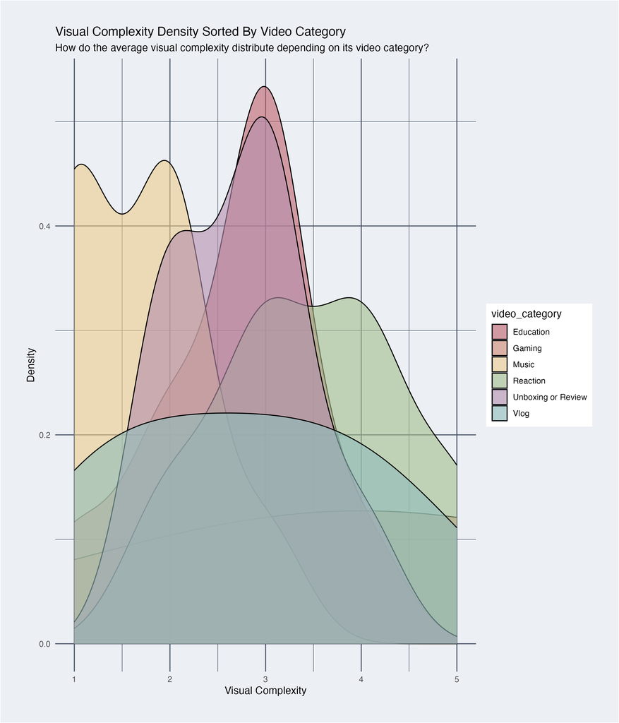

The first thing I want to find out from my data was which video category tend to have the most visually complex thumbnails. To find out, I created a density graph which shows the distribution of visual complexity across the different video categories.

Each time I collected data from a YouTube thumbnail, I noted their category as well as how “visually complex” the thumbnail is, giving it a score out of 5, with 1 being the least complex, and 5 being very complex.

Here I noticed that reaction videos tend to learn towards the more complex side of the plot, whereas music tended to have simpler thumbnails. This could be due to:

- That reaction videos often have more expressive human faces, as they want to show exaggerated reactions to make the viewers interested to keep watching, meaning that they might use more bright colours and visual elements.
- Music videos tend to draw the users in with the name of the musician or specific songs, so this is potentially a reason why music videos tend to have less complex, and less in your face thumbnails.

## Plot 2: Correlation between videos with faces, and it being more likely to be clickbait

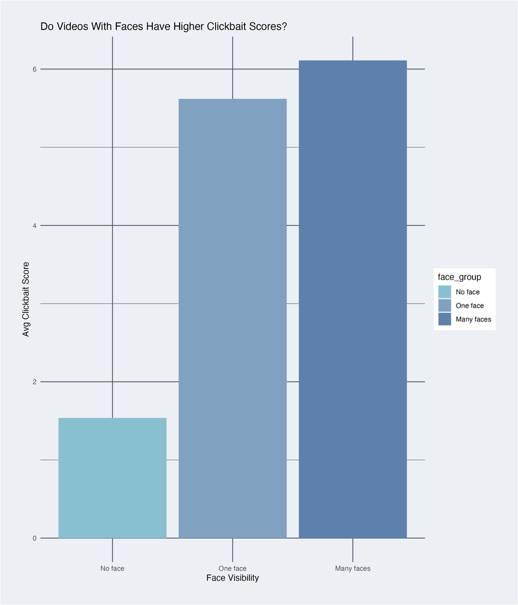

I have also collected data on how many faces appear in the thumbnails, and I have compared it to see if thumbnails with faces in them are perceived to be more “clickbait”.

The chart shows that thumbnails with no faces tend to have a much lower clickbait score than those with one or many faces in them. This could be due to the fact that humans are naturally drawn to faces, especially when they show exaggerated emotions or are accompanied with bright colours and many visual elements. This could also suggest that visual complexity plays a part in making a more clickbait thumbnail.

## Plot 3: How do the average clickbait score differ between days of the week?

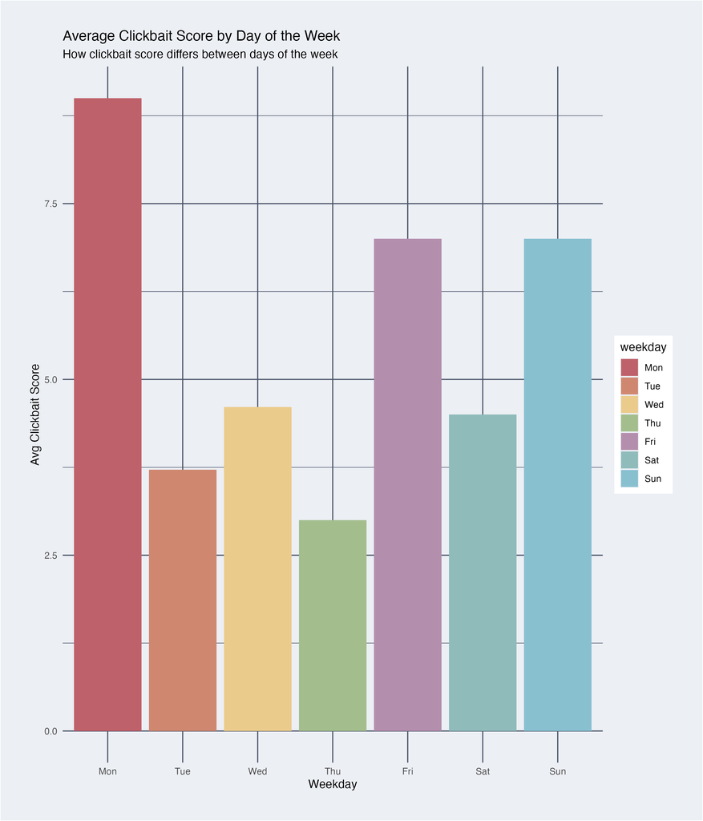

This ploit shows the average clickbait score for thumbnails, sorted by days of the week. Here monday has the highest clickbait score, followed by friday and sunday, with the rest of the week having lower scores. However, this data might be more accurate when done with a much larger dataset, due to the fact that I had a small sample size, as well as batch-completing the form.

These differences could also be affected by the YouTube algorithm and the content that I was exposed to on particular days of the week.

## Plot 4: How clickbaity is each video category?

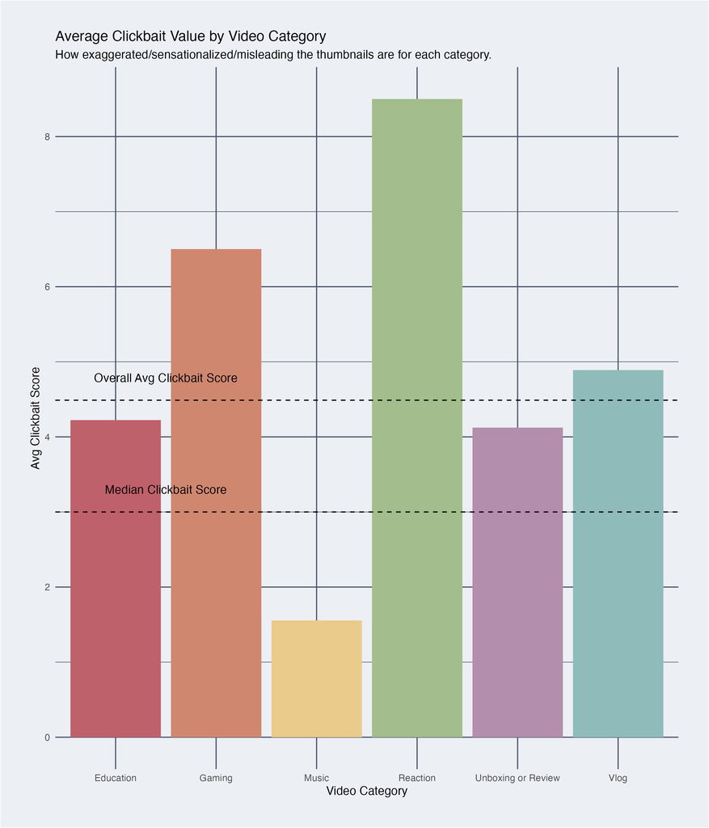

Here I have calculated the average clickbait score for each video category that I had collected data for.

- Reaction videos had the highest clickbait score, which is consistent with the plot 1, where reaction videos also had the highest visual complexity, suggesting that there might be a connection between the two.
- Music videos had the lowest clickbait score, and were also the least visually complex.

This supports my hypothesis that more visually complex thumbnails tend to be more clickbaity, especially in categories where they rely on more on exaggerated facial expressions (reaction videos).